# Practical Machine Learning Course Project

Gbenro Selere

August 20, 2015

## Introduction

Using devices such as Jawbone Up, Nike FuelBand, and Fitbit it is now possible to collect a large amount of data about personal activity relatively inexpensively. These type of devices are part of the quantified self movement - a group of enthusiasts who take measurements about themselves regularly to improve their health, to find patterns in their behavior, or because they are tech geeks. One thing that people regularly do is quantify how much of a particular activity they do, but they rarely quantify how well they do it. In this project, your goal will be to use data from accelerometers on the belt, forearm, arm, and dumbell of 6 participants. They were asked to perform barbell lifts correctly and incorrectly in 5 different ways. More information is available from the website here: [http://groupware.les.inf.puc-rio.br/har] (see the section on the Weight Lifting Exercise Dataset).

# Data

The training data for this project are available here:

[https://d396qusza40orc.cloudfront.net/predmachlearn/pml-training.csv]

The test data are available here:

[https://d396qusza40orc.cloudfront.net/predmachlearn/pml-testing.csv]

# Preprocessing

```r
library(caret)
library(rpart)
library(rattle)
```

```r
library(rpart.plot)
library(randomForest)
```

# Loading the files

```r
trainingDataUrl <-"https://d396qusza40orc.cloudfront.net/predmachlearn/pml-training.csv"
testDataUrl <- "https://d396qusza40orc.cloudfront.net/predmachlearn/pml-testing.csv"
trainingDataFile <- "./data/pml-training.csv"
testDataFile  <- "./data/pml-testing.csv"
if (!file.exists("./data")) {
  dir.create("./data")
}
if (!file.exists(trainingDataFile)) {
  download.file(trainingDataUrl, destfile=trainingDataFile, method="curl")
}
if (!file.exists(testDataFile)) {
  download.file(testDataUrl, destfile=testDataFile, method="curl")
}
```

# Reading the data

```r
trainingData <- read.csv("./data/pml-training.csv")
testData <- read.csv("./data/pml-testing.csv")
```

# Checking for missing values and removing irrelevant features from the dataset

Checking for missing values and subsetting away from the original data

```r
trainingData <- trainingData[, colSums(is.na(trainingData)) == 0]
testData <- testData[, colSums(is.na(testData)) == 0]
```

Getting rid of irrelavant columns

```r
# assign the classe column variables from the trainingData data frame to a data frame.
# This is because the classe column variables are the focus of the predictions and we need # to preserve them in their raw form.
classe <- trainingData$classe
# search through the column names in the data for those that match the search criteria
removeTrain.cols <- grepl("^X|timestamp|window", names(trainingData))
# subset the columns that don't match the search criteria
trainingData <- trainingData[, !removeTrain.cols]
# create a new data frame with numeric variables from the the trainingData data frame
trainDataCleaned <- trainingData[, sapply(trainingData, is.numeric)]
# assign the classe column variables from the original trainingData data frame to the new cleaned training data
trainDataCleaned$classe <- classe

# search through the column names in the data for those that match the search criteria
removeTest.cols <- grepl("^X|timestamp|window", names(testData))
# subset the columns that don't match the search criteria
testData <- testData[, !removeTest.cols]
# create a new data frame with numeric variables from the testData data frame
testDataCleaned <- testData[, sapply(testData, is.numeric)]
```

```r
dim(trainDataCleaned)
```

```
## [1] 19622    53
```

```r
dim(testDataCleaned)
```

```
## [1] 20 53
```

Now, the cleaned training data set contains 19622 observations and 53 variables, while the testing data set contains 20 observations and 53 variables. They have the same number of feature variables so we can now begin analysis.

# Partitioning the Data

Then, we can split the cleaned training set into a pure training data set (60%) and a validation data set (40%). We will use the validation data set to conduct cross validation in future steps.

```r
set.seed(13224)
inTrain <- createDataPartition(trainDataCleaned$classe, p=0.60, list = FALSE)
trainData <- trainDataCleaned[inTrain,]
testData <- trainDataCleaned[-inTrain,]
```

# Predictive Modelling

```r
modelControl <- trainControl(method = "cv", 10)
modelRF <- train(classe ~ ., data = trainData, method = "rf", trainControl = modelControl)
modelRF
```

```
## Random Forest
##
## 11776 samples
##    52 predictor
##     5 classes: 'A', 'B', 'C', 'D', 'E'
##
## No pre-processing
## Resampling: Bootstrapped (25 reps)
##
## Summary of sample sizes: 11776, 11776, 11776, 11776, 11776, 11776, ...
##
## Resampling results across tuning parameters:
##
##   mtry  Accuracy   Kappa      Accuracy SD  Kappa SD
##    2    0.9865584  0.9829961  0.002602016  0.003294779
##   27    0.9857831  0.9820171  0.002188992  0.002764339
##   52    0.9770275  0.9709446  0.004272477  0.005394688
##
## Accuracy was used to select the optimal model using  the largest value.
## The final value used for the model was mtry = 2.
```

The model is the evaluated on the validation data set

```r
predictRF <- predict(modelRF, testData)
confusionMatrix(testData$classe, predictRF)
```

```
## Confusion Matrix and Statistics
##
##           Reference
## Prediction    A    B    C    D    E
##          A 2230    2    0    0    0
##          B   11 1499    8    0    0
##          C    0    9 1356    3    0
##          D    0    0   21 1265    0
##          E    0    1    0    2 1439
##
## Overall Statistics
##
##                Accuracy : 0.9927
##                  95% CI : (0.9906, 0.9945)
##     No Information Rate : 0.2856
##     P-Value [Acc > NIR] : < 2.2e-16
##
##                   Kappa : 0.9908
##  Mcnemar's Test P-Value : NA
##
## Statistics by Class:
##
##                      Class: A Class: B Class: C Class: D Class: E
## Sensitivity            0.9951   0.9921   0.9791   0.9961   1.0000
## Specificity            0.9996   0.9970   0.9981   0.9968   0.9995
## Pos Pred Value         0.9991   0.9875   0.9912   0.9837   0.9979
## Neg Pred Value         0.9980   0.9981   0.9955   0.9992   1.0000
## Prevalence             0.2856   0.1926   0.1765   0.1619   0.1834
## Detection Rate         0.2842   0.1911   0.1728   0.1612   0.1834
## Detection Prevalence   0.2845   0.1935   0.1744   0.1639   0.1838
## Balanced Accuracy      0.9974   0.9945   0.9886   0.9964   0.9998
```

```r
modelAccuracy <- postResample(predictRF,testData$classe)

modelAccuracy
```

```
##  Accuracy     Kappa
## 0.9927352 0.9908095
```

```r
model.OutofsampleError <- as.numeric(confusionMatrix(testData$classe, predictRF)$overall[1])

model.OutofsampleError
```

```
## [1] 0.9927352
```

# Conducting predictions on the test set

```r
predResult <- predict(modelRF, testDataCleaned[, -length(names(testDataCleaned))])

predResult
```

```
##  [1] B A B A A E D B A A B C B A E E A B B B
## Levels: A B C D E
```

# Appendix

- fancyRpartPlot

```r
cartModel <- train(classe ~ ., data=trainData, method="rpart")
cartModel$finalModel
```

```
## n= 11776
##
## node), split, n, loss, yval, (yprob)
##       * denotes terminal node
##
##  1) root 11776 8428 A (0.28 0.19 0.17 0.16 0.18)
##    2) roll_belt< 130.5 10775 7439 A (0.31 0.21 0.19 0.18 0.11)
##      4) pitch_forearm< -33.95 960    6 A (0.99 0.0062 0 0 0) *
##      5) pitch_forearm>=-33.95 9815 7433 A (0.24 0.23 0.21 0.2 0.12)
##       10) magnet_dumbbell_y< 439.5 8304 5972 A (0.28 0.18 0.24 0.19 0.11)
##         20) roll_forearm< 124.5 5178 3091 A (0.4 0.19 0.18 0.17 0.057) *
##         21) roll_forearm>=124.5 3126 2071 C (0.078 0.18 0.34 0.22 0.18) *
##       11) magnet_dumbbell_y>=439.5 1511  761 B (0.033 0.5 0.04 0.23 0.2) *
##    3) roll_belt>=130.5 1001   12 E (0.012 0 0 0 0.99) *
```

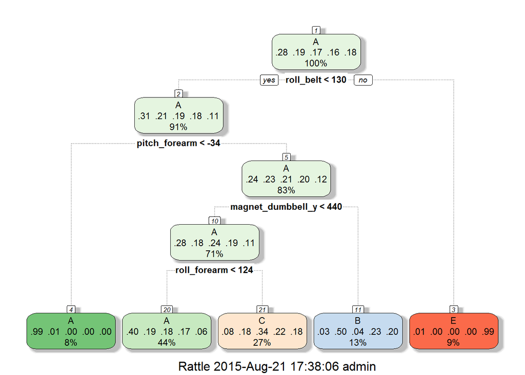

```r
fancyRpartPlot(cartModel$finalModel)
```

```r
dev.copy(png, file = "./figures/plot1.png")
```

```r
dev.off()
```

- prp plot for tree visualization

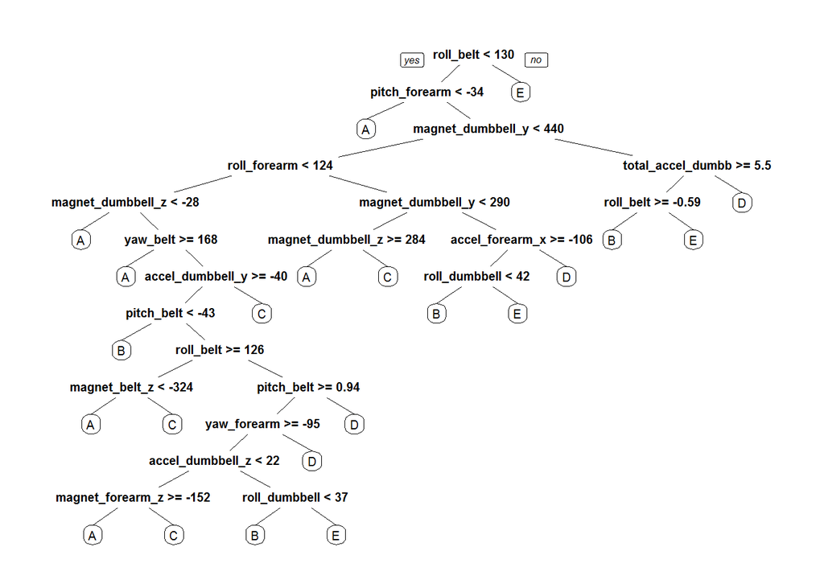

```r
treeModel <- rpart(classe ~. , data = trainData, method = "class")
prp(treeModel)
```

```r
dev.copy(png, file="./figures/plot2.png")
```

```r
dev.off()
```

- Submission script

```r
answers <- predResult
pml_write_files <- function(x){
  n = length(x)
  for(i in 1:n){
    filename = paste0("./prediction_results/problem_id_",i,".txt")
    write.table(x[i], file=filename, quote=FALSE,
                row.names=FALSE, col.names=FALSE)
  }
}
pml_write_files(answers)
```